# Cell Quality Control

Pijuan-Sala, Griffiths, Guibentif et al.: A single-cell resolution molecular roadmap from mouse gastrulation to early organogenesis.

26 August 2018

# Contents

```r
library(Matrix)
library(biomaRt)
library(ggplot2)
library(knitr)
library(scales)
library(viridis)

#core functions inc. colour palette
source("/nfs/research1/marioni/jonny/embryos/scripts/core_functions.R")


counts = readMM("/nfs/research1/marioni/jonny/embryos/data/raw_counts.mtx")
holder= file.copy("/nfs/research1/marioni/jonny/embryos/cellranger_out/sample_1/outs/raw_gene_bc_matrices/mm10/genes.tsv",
                  "/nfs/research1/marioni/jonny/embryos/data/genes.tsv")
genes = read.table("/nfs/research1/marioni/jonny/embryos/data/genes.tsv", stringsAsFactors = F)
barcodes = read.table("/nfs/research1/marioni/jonny/embryos/data/barcodes.tsv", stringsAsFactors = F)[,1]
exp_design = read.table("/nfs/research1/marioni/jonny/embryos/raw/meta/sample_stage_map.csv", sep = ",", header = TRUE)
```

# 1 Comparing sequencing depth

## 1.1 UMI counts

Our experimental design is from three batches - samples 1-11 in batch 1, samples 12-28 in batch 2, and samples 29-37 in batch 3. The number of UMIs per called cell is shown in Figure 1, split according to batch. There is no obvious difference.

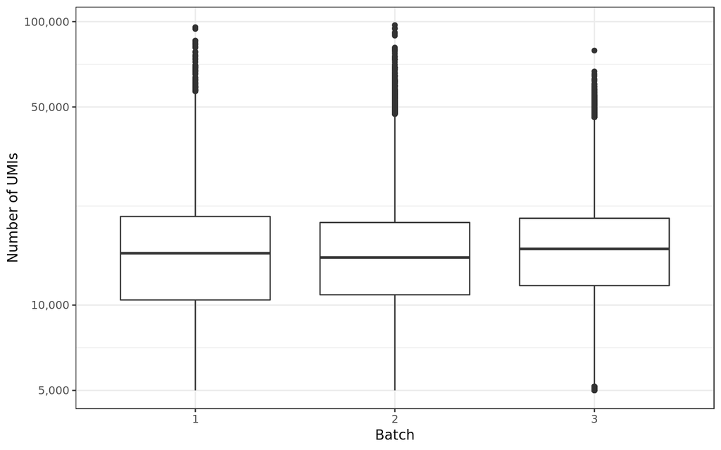

Figure 1: Barcode UMI counts for sequencing batches

```r
lib.sizes = Matrix::colSums(counts)

split_bc = strsplit(as.character(barcodes), "-", fixed = T)
samples = sapply(split_bc, function(x) x[2])

batch = sapply(samples, function(x){
  if(x %in% 1:11){
    return(1)
  } else if(x %in% 12:28){
    return(2)
  } else{
    return(3)
  }
})

plot_df = data.frame(lib = lib.sizes, sample = samples, batch = batch)


ggplot(plot_df, aes (x = factor(batch), y = lib)) +
  geom_boxplot() +
  theme_bw() +
  scale_y_log10(breaks = c(1000, 5000, 10000, 50000, 100000),
                             labels = c("1,000", "5,000", "10,000", "50,000", "100,000")) +
  labs(x = "Batch", y = "Number of UMIs")
```

## 1.2 Sequencing saturation

The 10X system uses unique molecular identifiers (UMIs). By considering how frequently the same UMIs have been sequenced, the saturation of sequencing can be estaimted (i.e. what % of captured molecules have been sequenced). Sample-wise median UMI counts are plotted alongside the sequencing saturations estimated by CellRanger in Figure 2.

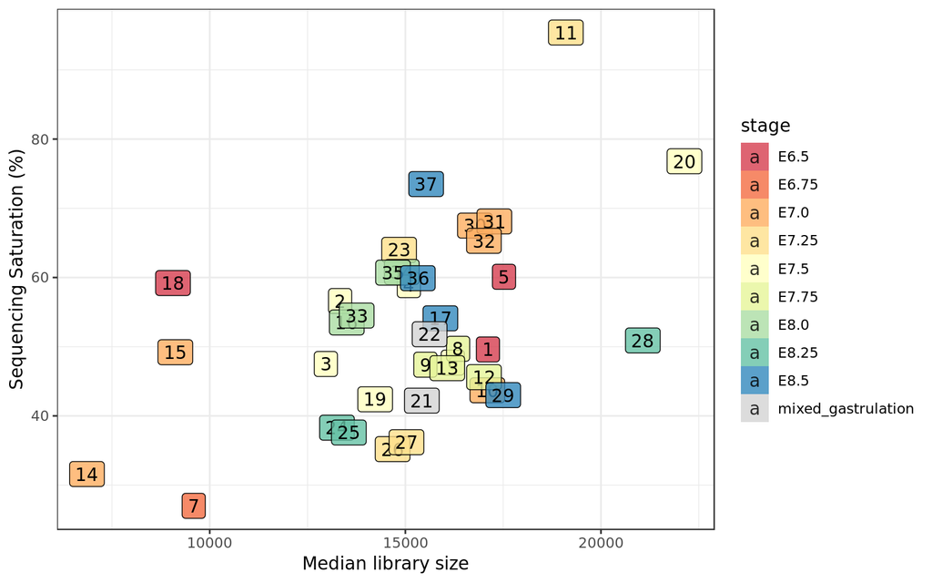

Figure 2: Sequencing saturations for each sample

```r
pdf = data.frame(sample = seq_along(unique(exp_design$sample)),
                 med_lib = sapply(seq_along(unique(exp_design$sample)), function(x) median(lib.sizes[samples == x])),
                 mean_lib = sapply(seq_along(unique(exp_design$sample)), function(x) mean(lib.sizes[samples == x])),
                 stage = sapply(seq_along(unique(exp_design$sample)), function(x) exp_design$stage[match(x, exp_design$sample)]),
                 saturation = sapply(seq_along(unique(exp_design$sample)), function(x){
                   tab = read.table(paste0("/nfs/research1/marioni/jonny/embryos/cellranger_out/sample_",
                                                                         x,
                                                                         "/outs/metrics_summary.csv"),
                                    header = TRUE,
                                    sep = ",")
                   stat = tab[1, "Sequencing.Saturation"]
                   return(as.numeric(substr(stat, 1, 4)))
                 }))

colors = c(brewer_pal(palette = "Spectral")(length(unique(pdf$stage))-1), "lightgrey")

ggplot(pdf, aes(x = med_lib, y = saturation, label = 1:nrow(pdf), fill = stage)) +
  geom_label(alpha = 0.8) +
  labs(x = "Median library size", y = "Sequencing Saturation (%)") +
  theme_bw() +
  scale_fill_manual(values = colors)
```

```r
plot_change = function(barcodes, logical_keep){
  split_bc = strsplit(as.character(barcodes), "-", fixed = T)
  samples = sapply(split_bc, function(x) x[2])

  pdf = data.frame(Sample = unique(samples),
                   Total = sapply(unique(samples), function(x) sum(samples == x)),
                   Dropped = sapply(unique(samples), function(x) sum(!logical_keep[samples == x])),
                   Retained = sapply(unique(samples), function(x) sum(logical_keep[samples == x])))

  p = ggplot(data = pdf) +
          geom_bar(mapping = aes(y = Total,
                                 x = factor(Sample, levels = unique(samples))),
                   fill = "darkgrey",
                   stat = "identity") +
          geom_bar(mapping = aes(y = Retained,
                                 x = factor(Sample, levels = unique(samples))),
                   fill = "coral",
                   stat = "identity") +
          geom_segment(mapping = aes(y = Total,
                                     yend = Retained,
                                     x = factor(Sample, levels = unique(samples)),
                                     xend = factor(Sample, levels = unique(samples))),
                       arrow = arrow(length = unit(0.1, "inches"))) +
          theme_bw() +
          labs(y = "Number of cells", x= "Sample")

  pdf = rbind(pdf, data.frame(Sample = "Total",
                              Total = length(barcodes),
                              Dropped = sum(!logical_keep),
                              Retained = sum(logical_keep)))

  return(list(plot = p, df = pdf))
}
```

# 2 Cell complexity thresholding

We remove cell libraries that have very low complexity: these are likely to be artefacts. Specifically, droplets that express fewer than 1000 different genes are removed.

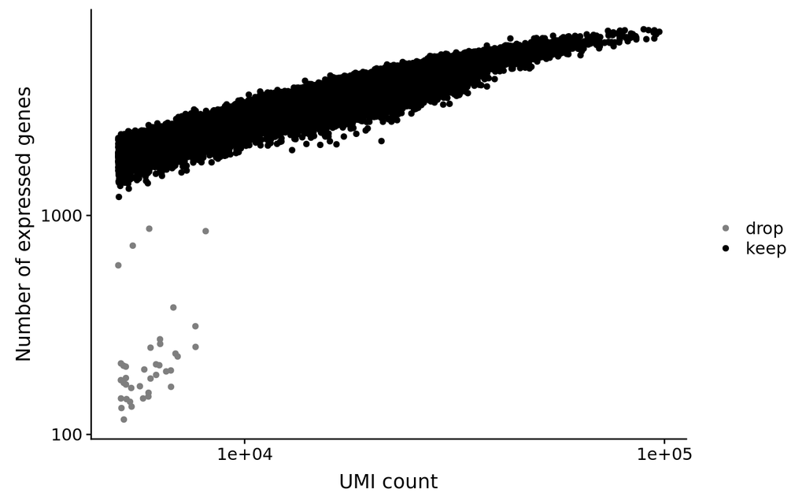

Figure 3: Cell library complexities are shown  
Black cells are retained, and grey cells are excluded.

```r
lib.sizes = Matrix::colSums(counts)

ngenes = Matrix::colSums(counts > 0)


qplot(lib.sizes, ngenes, col = ifelse(ngenes < 1000, "drop", "keep")) +
  scale_x_log10() +
  scale_y_log10() +
  labs(x = "UMI count", y = "Number of expressed genes") +
  scale_color_manual(values = c("drop" = "grey50", "keep" = "black"), name = "")
```

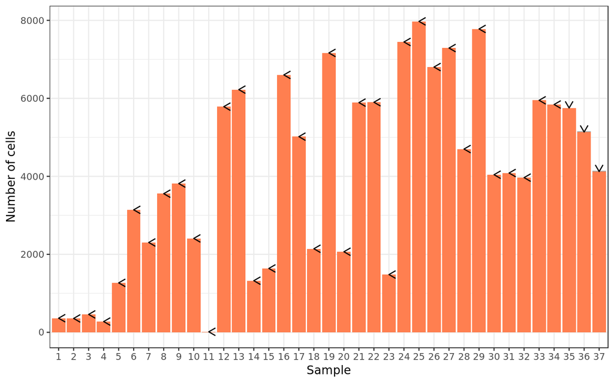

Figure 4: Cells dropped according to low library complexity thresholding

```r
gene_drop = plot_change(barcodes, logical_keep = ngenes > 1000 )

print(gene_drop$plot)
```

```r
kable(gene_drop$df, caption = "Cells dropped according to low library complexity thresholding.", row.names = FALSE)
```

Table 1: Cells dropped according to low library complexity thresholding

| Sample | Total | Dropped | Retained |
| --- | --- | --- | --- |
| 1 | 362 | 0 | 362 |
| 2 | 356 | 0 | 356 |
| 3 | 459 | 0 | 459 |
| 4 | 276 | 0 | 276 |
| 5 | 1268 | 0 | 1268 |
| 6 | 3141 | 0 | 3141 |
| 7 | 2304 | 0 | 2304 |
| 8 | 3555 | 0 | 3555 |
| 9 | 3815 | 0 | 3815 |
| 10 | 2408 | 0 | 2408 |
| 11 | 13 | 0 | 13 |
| 12 | 5787 | 0 | 5787 |
| 13 | 6224 | 0 | 6224 |
| 14 | 1324 | 0 | 1324 |
| 15 | 1638 | 0 | 1638 |
| 16 | 6601 | 0 | 6601 |
| 17 | 5018 | 0 | 5018 |
| 18 | 2143 | 0 | 2143 |
| 19 | 7165 | 0 | 7165 |
| 20 | 2066 | 0 | 2066 |
| 21 | 5891 | 0 | 5891 |
| 22 | 5900 | 0 | 5900 |
| 23 | 1481 | 0 | 1481 |
| 24 | 7446 | 0 | 7446 |
| 25 | 7974 | 0 | 7974 |
| 26 | 6803 | 0 | 6803 |
| 27 | 7290 | 0 | 7290 |
| 28 | 4700 | 0 | 4700 |
| 29 | 7780 | 0 | 7780 |
| 30 | 4042 | 0 | 4042 |
| 31 | 4085 | 0 | 4085 |
| 32 | 3967 | 0 | 3967 |
| 33 | 5950 | 0 | 5950 |
| 34 | 5842 | 0 | 5842 |
| 35 | 5754 | 1 | 5753 |
| 36 | 5156 | 20 | 5136 |
| 37 | 4140 | 17 | 4123 |
| Total | 150124 | 38 | 150086 |

```r
counts = counts[, ngenes > 1000]
barcodes = barcodes[ngenes > 1000]
ngenes = ngenes[ngenes > 1000]
```

# 3 Mitochondrial gene expression

Another useful QC metric is mitochondrial gene fraction: high measurements of mitochrondrial gene expression may indicate stressed cells, or incomplete lysis.

To identify a threshold for cell exclusion, we assume that the “standard” set of mitchondrial UMI fractions can be modelled by a normal distribution. We centre this distribution on the median value, with median absolute deviation estimated variance. We then consider cells outlying if their mitochondrial UMI fraction has a corresponding FDR-adjusted $p<0.05$, and exclude these. The cutoff is shown graphically in Figure 5, with quantification of cell exclusion in Figure 6 and Table 2

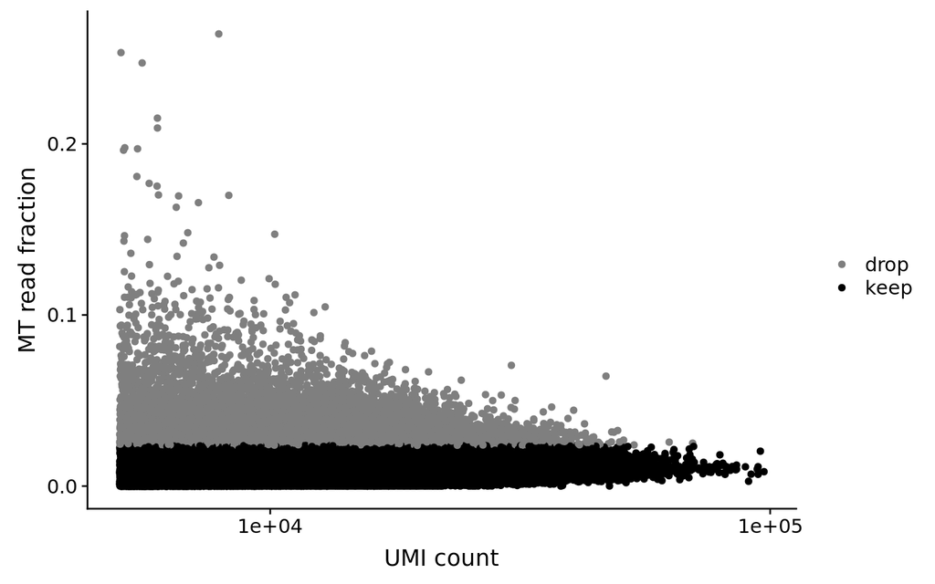

Figure 5: Mitochondrial read fractions

```r
lib.sizes = colSums(counts)

mouse_ensembl = useMart("ensembl")
mouse_ensembl = useDataset("mmusculus_gene_ensembl", mart = mouse_ensembl)

gene_map = getBM(attributes=c("ensembl_gene_id", "chromosome_name"), filters = "ensembl_gene_id", values = genes[,1], mart = mouse_ensembl)
mt.counts = counts[which(genes[,1] %in% gene_map$ensembl_gene_id[gene_map$chromosome_name=="MT"]),]
mt.fraction = colSums(mt.counts)/lib.sizes

#fit median-centered, MAD-variance normal
#crass 5%+
# mt.lim = qnorm(0.95, mean = median(mt.fraction), sd = mad(mt.fraction))
#fdr-corrected outliers
#technically this should be a pt, but the df. is astronomically high so this is essentially the same
mt.p = pnorm(mt.fraction, mean = median(mt.fraction), sd = mad(mt.fraction), lower.tail = FALSE)
mt.lim = min(mt.fraction[which(p.adjust(mt.p, method = "fdr") < 0.05)])

qplot(lib.sizes, mt.fraction, col = ifelse(mt.fraction>mt.lim, "drop", "keep")) +
  scale_x_log10() +
  labs(x = "UMI count", y = "MT read fraction") +
  scale_color_manual(values = c("drop" = "grey50", "keep" = "black"), name = "")
```

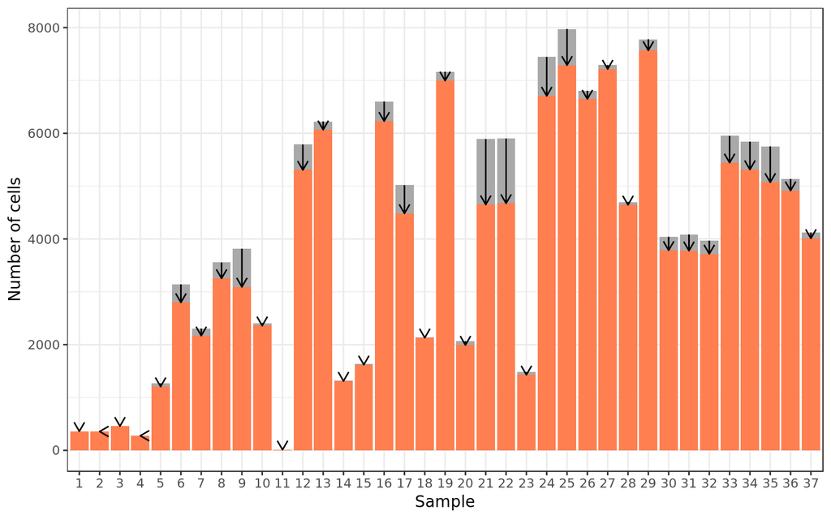

Figure 6: Cells dropped according to mitochondrial fraction threshold

```r
mt_drop = plot_change(barcodes, logical_keep = mt.fraction<mt.lim )

print(mt_drop$plot)
```

```r
kable(mt_drop$df, caption = "Cells dropped according to mitochondrial fraction threshold", row.names = FALSE)
```

Table 2: Cells dropped according to mitochondrial fraction threshold

| Sample | Total | Dropped | Retained |
| --- | --- | --- | --- |
| 1 | 362 | 2 | 360 |
| 2 | 356 | 0 | 356 |
| 3 | 459 | 1 | 458 |
| 4 | 276 | 0 | 276 |
| 5 | 1268 | 61 | 1207 |
| 6 | 3141 | 343 | 2798 |
| 7 | 2304 | 135 | 2169 |
| 8 | 3555 | 301 | 3254 |
| 9 | 3815 | 722 | 3093 |
| 10 | 2408 | 49 | 2359 |
| 11 | 13 | 2 | 11 |
| 12 | 5787 | 482 | 5305 |
| 13 | 6224 | 156 | 6068 |
| 14 | 1324 | 13 | 1311 |
| 15 | 1638 | 18 | 1620 |
| 16 | 6601 | 371 | 6230 |
| 17 | 5018 | 535 | 4483 |
| 18 | 2143 | 13 | 2130 |
| 19 | 7165 | 169 | 6996 |
| 20 | 2066 | 74 | 1992 |
| 21 | 5891 | 1240 | 4651 |
| 22 | 5900 | 1226 | 4674 |
| 23 | 1481 | 52 | 1429 |
| 24 | 7446 | 739 | 6707 |
| 25 | 7974 | 685 | 7289 |
| 26 | 6803 | 154 | 6649 |
| 27 | 7290 | 74 | 7216 |
| 28 | 4700 | 54 | 4646 |
| 29 | 7780 | 211 | 7569 |
| 30 | 4042 | 257 | 3785 |
| 31 | 4085 | 307 | 3778 |
| 32 | 3967 | 249 | 3718 |
| 33 | 5950 | 507 | 5443 |
| 34 | 5842 | 528 | 5314 |
| 35 | 5753 | 681 | 5072 |
| 36 | 5136 | 221 | 4915 |
| 37 | 4123 | 112 | 4011 |
| Total | 150086 | 10744 | 139342 |

```r
counts = counts[, mt.fraction < mt.lim]
barcodes = barcodes[mt.fraction < mt.lim]
mt.fraction = mt.fraction[mt.fraction < mt.lim]
```

The cutoff was at 2.37%

# 4 Number of detected genes

The relationship between the number of UMIs per cell and the number of detected genes per cell is shown in Figure 7. Note that these are well behaved between samples.

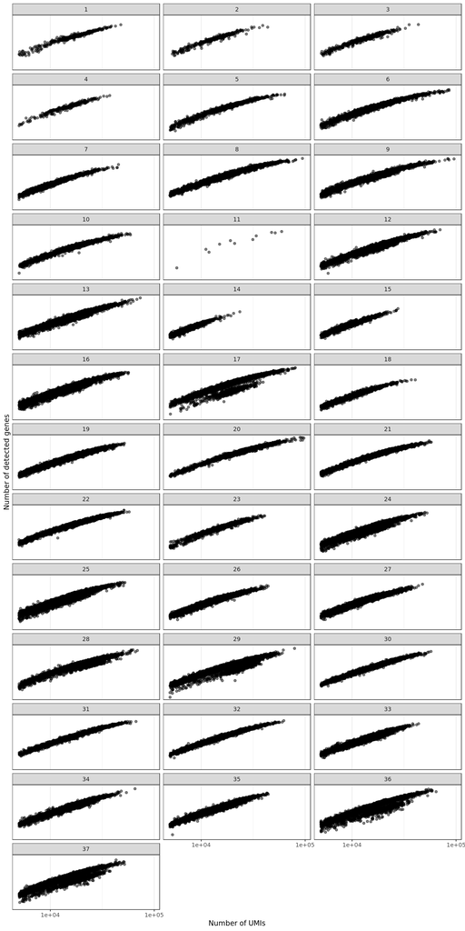

Figure 7: Sample-wise plots of retained libraries

```r
lib.sizes = colSums(counts)
n.genes = colSums(counts>0)

split_bc = strsplit(as.character(barcodes), "-", fixed = T)
bcs = sapply(split_bc, function(x) x[1])
samples = sapply(split_bc, function(x) x[2])

plot_df = data.frame(lib = lib.sizes, genes = n.genes, sample = samples)
plot_df = plot_df[sample(nrow(plot_df), nrow(plot_df), replace = FALSE),]

p = ggplot(plot_df, aes(x = lib, y = genes)) +
  geom_point(alpha = 0.5) +
  scale_colour_Publication() +
  scale_y_log10() +
  scale_x_log10() +
  theme_bw() +
  facet_wrap(~factor(sample, levels = unique(sample)[order(nchar(unique(as.character(sample))), unique(sample))]), ncol = 3) +
  labs(x = "Number of UMIs", y = "Number of detected genes")

suppressWarnings(plot(p))
```

You may note a population of cells in Sample 17 which show considerably lower complexity than those in other samples. These are blood cells, as is shown via expression of the haemoglobin gene *Hbb-bh1* in Figure 8. These cells express very high levels of the haemoglobin genes, which effectively reduces their transcriptome complexity for a given number of captured RNAs.

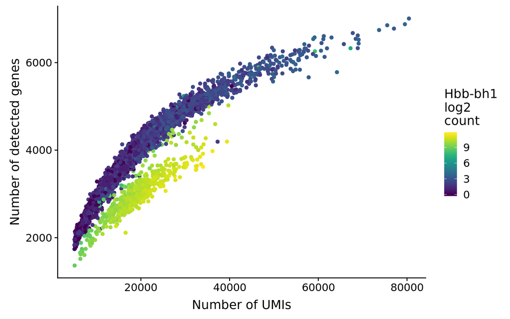

Figure 8: Expression of Hbb-bh1 shown for cells of different sizes and complexities

```r
lib.sizes = colSums(counts)
n.genes = colSums(counts>0)

split_bc = strsplit(as.character(barcodes), "-", fixed = T)
bcs = sapply(split_bc, function(x) x[1])
samples = sapply(split_bc, function(x) x[2])

plot_df = data.frame(lib = lib.sizes, genes = n.genes, sample = samples)
plot_df = plot_df[plot_df$sample == 17,]
plot_df$count = as.numeric(counts[match("Hbb-bh1", genes[,2]), samples == 17])

ggplot(plot_df, aes(x = lib, y = genes, col = log2(count+1))) +
  geom_point() +
  scale_color_viridis(name = "Hbb-bh1\nlog2\ncount") +
  labs(x = "Number of UMIs", y = "Number of detected genes")
```

# 5 Inter-sample comparisons

The distributions of UMI counts (Figure 9) and mitchondrial read fractions (Figure 10) are shown between the samples, below.

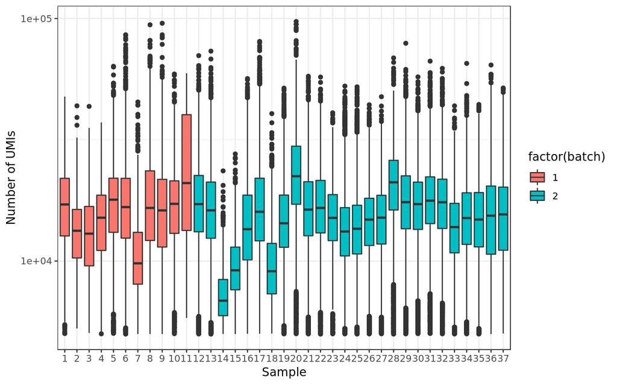

Figure 9: Sample-wise UMI count distributions

```r
batch = ifelse(as.numeric(samples) <= 11,
               1,
               2)

p = ggplot(data.frame(lib = lib.sizes, sample = samples), aes (x = factor(sample, levels = unique(sample)),
                                                           y = lib.sizes, fill = factor(batch))) +
  geom_boxplot() +
  theme_bw() +
  scale_y_log10() +
  labs(x = "Sample", y = "Number of UMIs")+
  scale_color_brewer(palette = "Set1", name = "Sequencing\nbatch")

suppressWarnings(plot(p))
```

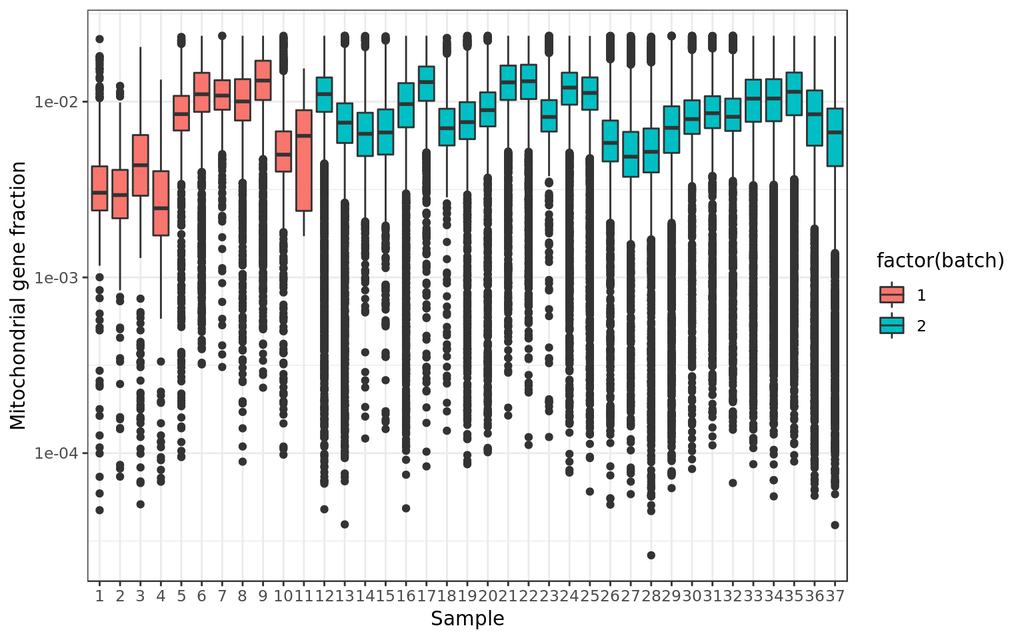

Figure 10: Sample-wise mitochrondrial UMI distributions

```r
p = ggplot(data.frame(mt = mt.fraction, sample = samples), aes (x = factor(sample, levels = unique(sample)),
                                                           y = mt, fill = factor(batch))) +
  geom_boxplot() +
  theme_bw() +
  scale_y_log10() +
  labs(x = "Sample", y = "Mitochondrial gene fraction") +
  scale_color_brewer(palette = "Set1", name = "Sequencing\nbatch")

suppressWarnings(plot(p))
```

A similar comparison is now made across stage, considering the distributions of library size (Figure 11) and mitochondrial read fractions (Figure 12).

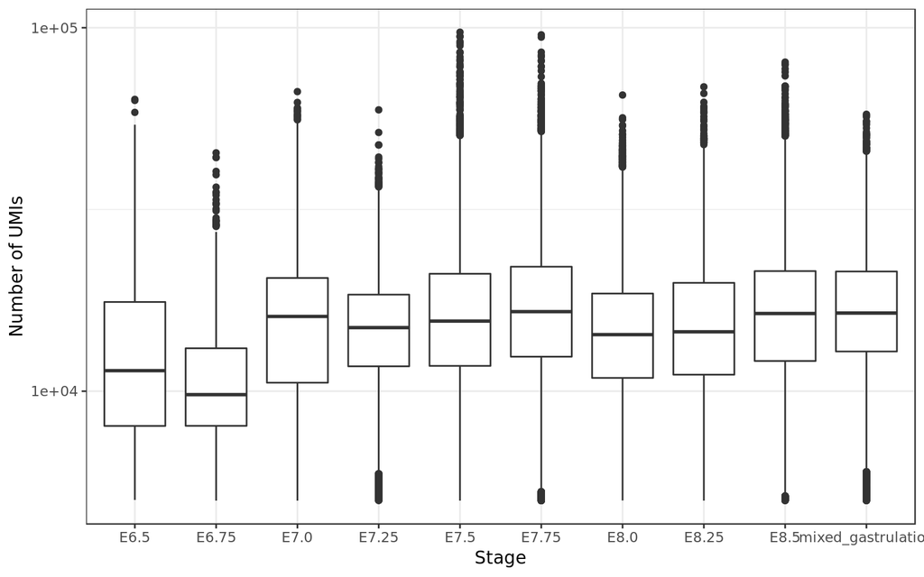

Figure 11: Stage-wise UMI count distributions

```r
stage_match = read.table("/nfs/research1/marioni/jonny/embryos/raw/meta/sample_stage_map.csv", sep = ",", header = TRUE)

pdf = data.frame(mt = mt.fraction, sample = samples, lib.size = lib.sizes, stage = stage_match$stage[match(samples, stage_match$sample)])

p = ggplot(pdf, aes(x = factor(stage), y= lib.size)) +
  geom_boxplot() +
  theme_bw() +
  scale_y_log10() +
  labs(x = "Stage", y = "Number of UMIs")

suppressWarnings(plot(p))
```

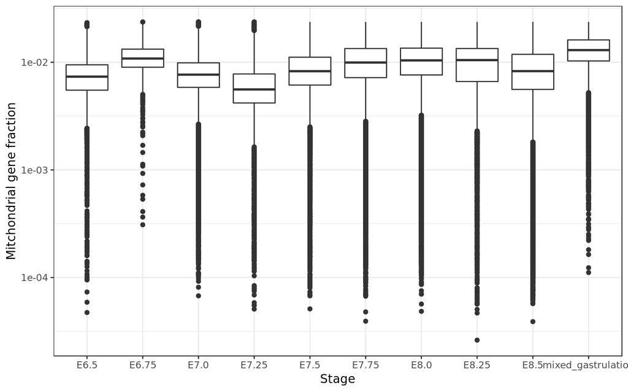

```r
p = ggplot(pdf, aes(x = factor(stage), y=mt.fraction)) +
  geom_boxplot() +
  theme_bw() +
  scale_y_log10() +
  labs(x = "Stage", y = "Mitchondrial gene fraction")

suppressWarnings(plot(p))
```

# 6 Remove sample 11

Clearly, something has gone wrong with sample 11, as so few cells were captured. We therefore remove all cells from this sample, as it has likely entirely QC-failed.

```r
counts = counts[ , samples != 11]
barcodes = barcodes[samples != 11]
```

# 7 Make metadata

We now save a table of metadata, recording for each cell its barcode, sample, developmental stage and sequencing batch. Additionally, we store Thieler stage (TS) information for each cell. Specifically, we label E6.5-E6.75 cells as TS9, E7.0-E7.25 as TS10, E7.5-E7.75 as TS11, and E8.0-E8.5 as TS12. Note that two samples were formed of embryos of a variety of stages. These are labelled as a “mixed_gastrulation” timepoint, at Theiler stage “TS9-10”

```r
split_bc = strsplit(as.character(barcodes), "-", fixed = T)
bcs = sapply(split_bc, function(x) x[1])
samples = sapply(split_bc, function(x) x[2])



meta = data.frame(cell = paste0("cell_", 1:ncol(counts)),
                  barcode = bcs,
                  sample = as.numeric(samples),
                  stage = stage_match$stage[match(samples, stage_match$sample)],
                  batch = stage_match$batch[match(samples, stage_match$sample)])

meta$theiler = sapply(meta$stage, function(x){
  if(x == "mixed_gastrulation"){
    return("TS9-10")
  } else if(x %in% c("E6.5", "E6.75")){
    return("TS9")
  } else if(x %in% c("E7.0", "E7.25")){
    return("TS10")
  } else if(x %in% c("E7.5", "E7.75")){
    return("TS11")
  } else if(x %in% c("E8.0", "E8.25", "E8.5")){
    return("TS12")
  } else {
    return(NA)
  }
})
```

This procedure has left us with 139331 cells, distributed between samples and stages as shown in Table 3.

```r
tab = as.matrix(table(meta$sample, meta$stage))

new_rownames = c("Total", rownames(tab))
tab = rbind(sapply(colnames(tab), function(x) sum(meta$stage == x)),
            tab)
rownames(tab) = new_rownames

pt = kable(tab, caption = "Number of cells retained for analysis")
pt
```

Table 3: Number of cells retained for analysis

|  | E6.5 | E6.75 | E7.0 | E7.25 | E7.5 | E7.75 | E8.0 | E8.25 | E8.5 | mixed_gastrulation |
| --- | --- | --- | --- | --- | --- | --- | --- | --- | --- | --- |
| Total | 3697 | 2169 | 16571 | 15294 | 12876 | 17720 | 22059 | 18642 | 20978 | 9325 |
| 1 | 360 | 0 | 0 | 0 | 0 | 0 | 0 | 0 | 0 | 0 |
| 2 | 0 | 0 | 0 | 0 | 356 | 0 | 0 | 0 | 0 | 0 |
| 3 | 0 | 0 | 0 | 0 | 458 | 0 | 0 | 0 | 0 | 0 |
| 4 | 0 | 0 | 0 | 0 | 276 | 0 | 0 | 0 | 0 | 0 |
| 5 | 1207 | 0 | 0 | 0 | 0 | 0 | 0 | 0 | 0 | 0 |
| 6 | 0 | 0 | 0 | 0 | 2798 | 0 | 0 | 0 | 0 | 0 |
| 7 | 0 | 2169 | 0 | 0 | 0 | 0 | 0 | 0 | 0 | 0 |
| 8 | 0 | 0 | 0 | 0 | 0 | 3254 | 0 | 0 | 0 | 0 |
| 9 | 0 | 0 | 0 | 0 | 0 | 3093 | 0 | 0 | 0 | 0 |
| 10 | 0 | 0 | 2359 | 0 | 0 | 0 | 0 | 0 | 0 | 0 |
| 12 | 0 | 0 | 0 | 0 | 0 | 5305 | 0 | 0 | 0 | 0 |
| 13 | 0 | 0 | 0 | 0 | 0 | 6068 | 0 | 0 | 0 | 0 |
| 14 | 0 | 0 | 1311 | 0 | 0 | 0 | 0 | 0 | 0 | 0 |
| 15 | 0 | 0 | 1620 | 0 | 0 | 0 | 0 | 0 | 0 | 0 |
| 16 | 0 | 0 | 0 | 0 | 0 | 0 | 6230 | 0 | 0 | 0 |
| 17 | 0 | 0 | 0 | 0 | 0 | 0 | 0 | 0 | 4483 | 0 |
| 18 | 2130 | 0 | 0 | 0 | 0 | 0 | 0 | 0 | 0 | 0 |
| 19 | 0 | 0 | 0 | 0 | 6996 | 0 | 0 | 0 | 0 | 0 |
| 20 | 0 | 0 | 0 | 0 | 1992 | 0 | 0 | 0 | 0 | 0 |
| 21 | 0 | 0 | 0 | 0 | 0 | 0 | 0 | 0 | 0 | 4651 |
| 22 | 0 | 0 | 0 | 0 | 0 | 0 | 0 | 0 | 0 | 4674 |
| 23 | 0 | 0 | 0 | 1429 | 0 | 0 | 0 | 0 | 0 | 0 |
| 24 | 0 | 0 | 0 | 0 | 0 | 0 | 0 | 6707 | 0 | 0 |
| 25 | 0 | 0 | 0 | 0 | 0 | 0 | 0 | 7289 | 0 | 0 |
| 26 | 0 | 0 | 0 | 6649 | 0 | 0 | 0 | 0 | 0 | 0 |
| 27 | 0 | 0 | 0 | 7216 | 0 | 0 | 0 | 0 | 0 | 0 |
| 28 | 0 | 0 | 0 | 0 | 0 | 0 | 0 | 4646 | 0 | 0 |
| 29 | 0 | 0 | 0 | 0 | 0 | 0 | 0 | 0 | 7569 | 0 |
| 30 | 0 | 0 | 3785 | 0 | 0 | 0 | 0 | 0 | 0 | 0 |
| 31 | 0 | 0 | 3778 | 0 | 0 | 0 | 0 | 0 | 0 | 0 |
| 32 | 0 | 0 | 3718 | 0 | 0 | 0 | 0 | 0 | 0 | 0 |
| 33 | 0 | 0 | 0 | 0 | 0 | 0 | 5443 | 0 | 0 | 0 |
| 34 | 0 | 0 | 0 | 0 | 0 | 0 | 5314 | 0 | 0 | 0 |
| 35 | 0 | 0 | 0 | 0 | 0 | 0 | 5072 | 0 | 0 | 0 |
| 36 | 0 | 0 | 0 | 0 | 0 | 0 | 0 | 0 | 4915 | 0 |
| 37 | 0 | 0 | 0 | 0 | 0 | 0 | 0 | 0 | 4011 | 0 |

# 8 Expected vs. retained cells

10X provides estimates of the number of cells to expect to capture, given an input number of cells. Our final number of cells and the expected number of recovered cells is shown in Figure 13.

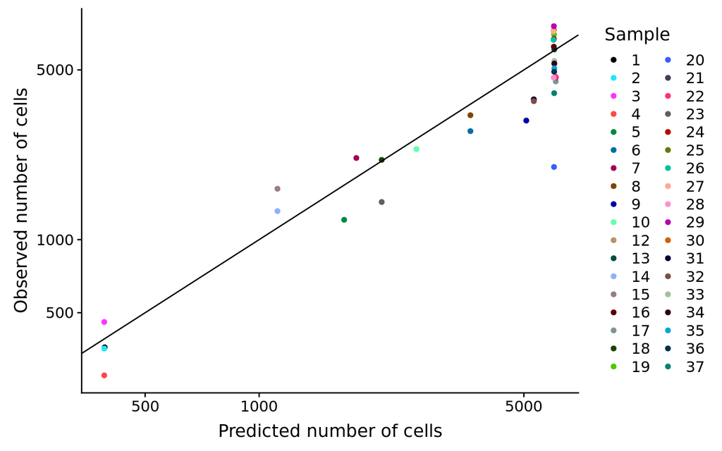

Figure 13: Expected vs observed number of recovered cells  
The black line has gradient 1, intercept 0.

```r
exp = read.table("/nfs/research1/marioni/jonny/embryos/raw/meta/exp_cells.tab", sep = "\t", header = TRUE)
exp = exp[exp$sample!=11,]

exp$obs = sapply(exp$sample, function(x) sum(meta$sample == x))
exp$cells = as.numeric(gsub(",", "", exp$cells))

ggplot(exp, aes(x = cells, y = obs, col = factor(sample))) +
  geom_point() +
  scale_colour_Publication(name = "Sample") +
  scale_x_log10(breaks = c(500, 1000, 5000)) +
  scale_y_log10(breaks = c(500, 1000, 5000)) +
  labs(x = "Predicted number of cells", y = "Observed number of cells") +
  geom_abline(slope = 1, intercept = 0)
```

# 9 Save data

The data is now saved to disk.

```r
null_holder = writeMM(counts, file = "/nfs/research1/marioni/jonny/embryos/data/raw_counts.mtx")
saveRDS(as(counts, "dgCMatrix"), file = "/nfs/research1/marioni/jonny/embryos/data/raw_counts.rds")
write.table(barcodes, file = "/nfs/research1/marioni/jonny/embryos/data/barcodes.tsv", row.names = F, col.names = F, quote = F, sep = "\t")
write.table(meta, file = "/nfs/research1/marioni/jonny/embryos/data/meta.tab", row.names = F, col.names = T, quote = F, sep = "\t")
```